# Data Science Capstone Milestone Report

E. Moller

August 4, 2017

## Objective

The objectives of the Milestone Report are to show familiarity with the dataset by loading, cleaning and exploring properties of the dataset, and begin planning the forthcoming application and algorithm.

## Getting and Cleaning the Data

```r
library(stringi)
library(tm)
library(SnowballC)
library(RWeka)
```

Download the data…

```r
if (!file.exists("Coursera-SwiftKey.zip")){
  download.file("https://d396qusza40orc.cloudfront.net/dsscapstone/dataset/Coursera-SwiftKey.zip",destfile = "Coursera-Swiftkey.zip")
  unzip("Coursera-SwiftKey.zip")
}
```

There are four languages sets of files included in the zip file - English, Finnish, German and Russian - we will just use the english set for now.

```r
blogs <- readLines("final/en_US/en_US.blogs.txt",skipNul = TRUE)
news <- readLines("final/en_US/en_US.news.txt",skipNul = TRUE)
twitter <- readLines("final/en_US/en_US.twitter.txt",skipNul = TRUE)
```

### Basic Summaries to Explore the data

Number of Words

```r
blogsWords <- stri_count_words(blogs)
newsWords <- stri_count_words(news)
twitterWords <- stri_count_words(twitter)
```

Number of Lines in Each File

```r
blogsLines <- length(blogs)
newsLines <- length(news)
twitterLines <- length(twitter)
```

Print Summary of Word and Line Counts

```r
data.frame(File=c("blogs","news","twitter"),Wordcount=c(sum(blogsWords),sum(newsWords),sum(twitterWords)),Linecount=c(blogsLines,newsLines,twitterLines))
```

```
##      File Wordcount Linecount
## 1   blogs  37546246    899288
## 2    news  34762395   1010242
## 3 twitter  30093410   2360148
```

### Take a Sample of the Data

These are very large datasets, so we should take a sample of the datasets to manipulate.

```r
#Take a sample
blogs <- blogs[rbinom(blogsLines*.005,blogsLines,.5)]
news <- news[rbinom(newsLines*.005,newsLines,.5)]
twitter <- twitter[rbinom(twitterLines*.005,twitterLines,.5)]

#Put into one file
sampleData <- c(blogs,news,twitter)
```

### Get Number of Words and Lines in Sample Dataset

```r
sum(stri_count_words(sampleData))
```

```
## [1] 515950
```

```r
length(sampleData)
```

```
## [1] 21347
```

### Put Data into Separate Directory to Clean

```r
dir.create("sampleDataDir/", showWarnings = FALSE)
writeLines(sampleData, "./sampleDataDir/sampleData.csv")
sampleData <- Corpus(DirSource("./sampleDataDir"))
```

### Clean the Data

We will use the tm package to clean the data.

```r
# Remove extra whitespace - multiple whitespace characters are collapsed to a single blank.
sampleData <- tm_map(sampleData, stripWhitespace)

# Remove punctuation marks from the document
sampleData <- tm_map(sampleData, removePunctuation)

# Remove numbers from the document
sampleData <- tm_map(sampleData, removeNumbers)

# Make all letters lowercase
sampleData <- tm_map(sampleData, content_transformer(tolower))

# Stem words - stem words in a text document using Porter's stemming algorithm.
sampleData <- tm_map(sampleData, stemDocument)
```

## Exploratory Analysis

To explore the data, we will look at the n-grams (bigrams and trigrams) - “In the fields of computational linguistics and probability, an n-gram is a contiguous sequence of n items from a given sequence of text or speech. The items can be phonemes, syllables, letters, words or base pairs according to the application.” With the ultimate goal of wanting to predict the following word, we need to have a base of understanding of what pairs or triads of words are most often seen together. We will have to eventually figure out what to do with an unexpected word.

### Bigrams

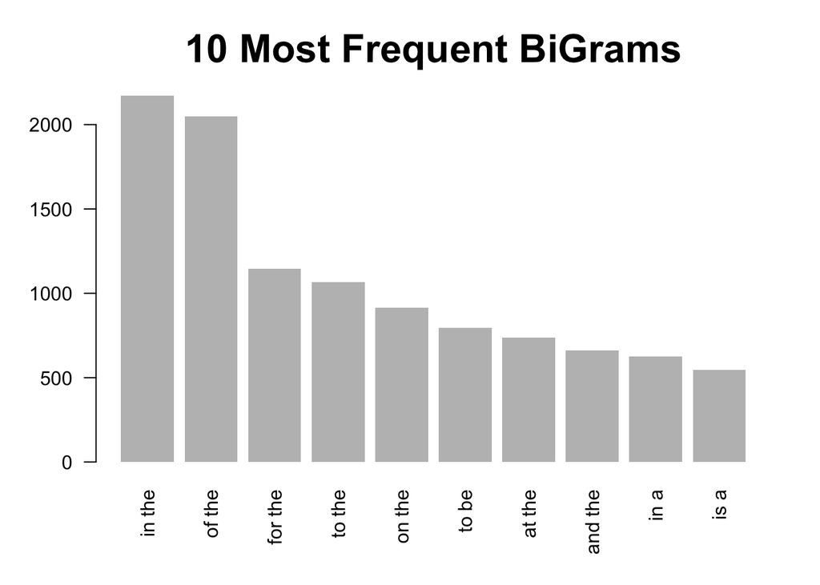

```r
bigram <- NGramTokenizer(sampleData, Weka_control(min = 2, max = 2))
frequency.bigram <- data.frame(table(bigram))
order.bigram <- frequency.bigram[order(frequency.bigram$Freq,decreasing = TRUE),]
top10bigram <- head(order.bigram,10)
barplot(top10bigram$Freq, names.arg = top10bigram$bigram, border=NA, las=2, main="10 Most Frequent BiGrams", cex.main=2)
```

### Trigrams

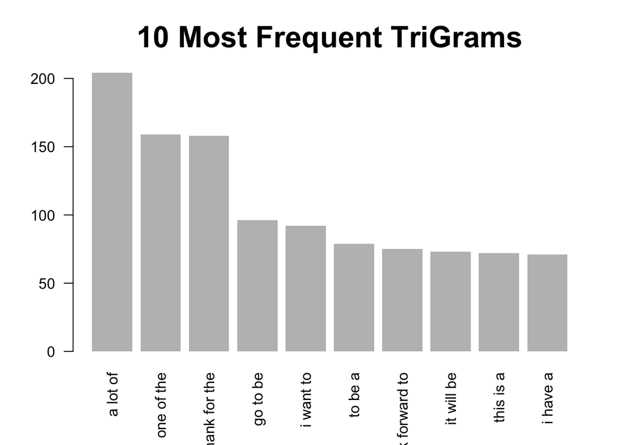

```r
trigram <- NGramTokenizer(sampleData, Weka_control(min = 3, max = 3))
frequency.trigram <- data.frame(table(trigram))
order.trigram <- frequency.trigram[order(frequency.trigram$Freq,decreasing = TRUE),]
top10trigram <- head(order.trigram,10)
barplot(top10trigram$Freq, names.arg = top10trigram$trigram, border=NA, las=2, main="10 Most Frequent TriGrams", cex.main=2)
```

## Plans for Creating a Prediction Algroithm and Shiny App

I would like to make more small samples to test models.

For modeling, I would like to use the n-grams to create a predictive model. My app will display three word choices for the next predicted word. I would like to play with taking out the “stop words” - i.e. - is, in, the. This seems to be a lot of the bigram words, so possibly doing another bigram without those words as well.